# Human Activity Recognition

David Shupe

December 27, 2015

## Executive Summary

This report concerns human activity recognition, for a dataset in which various “fitness tracker”-style measurements were recorded while study participants performed weightlifting exercises with good form and with poor form. The training set included 5 classes for the exercises. We removed features containing mostly NA values, as well as several features that were simply identification information (like participant name and time the data were taken). We trained both a CART model and a random forest model. The simple CART model reached only a 50% accuracy on the training set but the random forest model reached 99.4% accuracy on the same set. The random forest model predicted all 20 test cases correctly.

## Data Input and Preprocessing

The training set was provided in ‘pml-training.csv’ and the test set in ‘pml-testing.csv’. After some iteration, we read in the values treating ‘NA’, blank, or the Excel-ism ‘#DIV/0!’ as missing values.

```r
training <- read.csv('pml-training.csv', na.strings=c(" ","#DIV/0!","NA"))
test <- read.csv('pml-testing.csv',na.strings=c(" ","#DIV/0!","NA"))
training$classe <- as.factor(training$classe)
```

A summary of the training set shows many of the 160 columns are populated mostly with NAs. We remove the columns that have more than 1000 NAs. This reduces the number of columns from 160 to 60. Then we remove the first 7 columns. These contain identifying information such as an index, the name of the participant, timestamps of when the data were recorded, and whether the row is the start of a time window. We’d like our model to apply regardless of participant or when the data were taken, so our intuition is to remove these features, leaving us only with the “fitness tracker”-style measurements.

```r
good_training <- training[,colSums(is.na(training)) < 1000]
good_training <- good_training[,8:ncol(good_training)]
na_count <- data.frame(sapply(good_training, function(y) sum(length(which(is.na(y))))))
```

We are left with no NA values, so we won’t have to impute missing values in the pre-processing set.

We apply centering and scaling to the training features. The preprocessing steps are saved for later application to the test set.

```r
trainX <- good_training[,names(good_training) != 'classe']
preProcValues <- preProcess(trainX, method = c("center", "scale"))
scaledTrain <- predict(preProcValues, trainX)
scaledTrain$classe <- good_training$classe
```

We will hold out 20% of the training set for the purposes of computing out-of-sample error.

```r
set.seed(33833)
inTrain <- createDataPartition(y=scaledTrain$classe, p=0.8, list=FALSE)
finalTrain <- scaledTrain[inTrain,]
heldOutTrain <- scaledTrain[-inTrain,]
```

## CART model

First we fit a CART model. Following the caret tutorial by Max Kuhn, we use 10-fold cross-validation with 3 repeats.

```r
cvCtrl <- trainControl(method = "repeatedcv", repeats = 3)
set.seed(33833)
rpartTune <- train(classe ~ ., method = "rpart", data=finalTrain,
                    trControl = cvCtrl)
```

How did we do?

```r
rpartTune
```

```
## CART
##
## 15699 samples
##    52 predictor
##     5 classes: 'A', 'B', 'C', 'D', 'E'
##
## No pre-processing
## Resampling: Cross-Validated (10 fold, repeated 3 times)
## Summary of sample sizes: 14128, 14130, 14131, 14130, 14129, 14129, ...
## Resampling results across tuning parameters:
##
##   cp          Accuracy   Kappa       Accuracy SD  Kappa SD
##   0.03702715  0.4994606  0.34672524  0.01694517   0.02481330
##   0.06002077  0.4490305  0.26442147  0.05983284   0.10066530
##   0.11401869  0.3182121  0.05159457  0.03954051   0.06016613
##
## Accuracy was used to select the optimal model using  the largest value.
## The final value used for the model was cp = 0.03702715.
```

Wow, 50% accuracy is pretty lousy.

What are the most important variables?

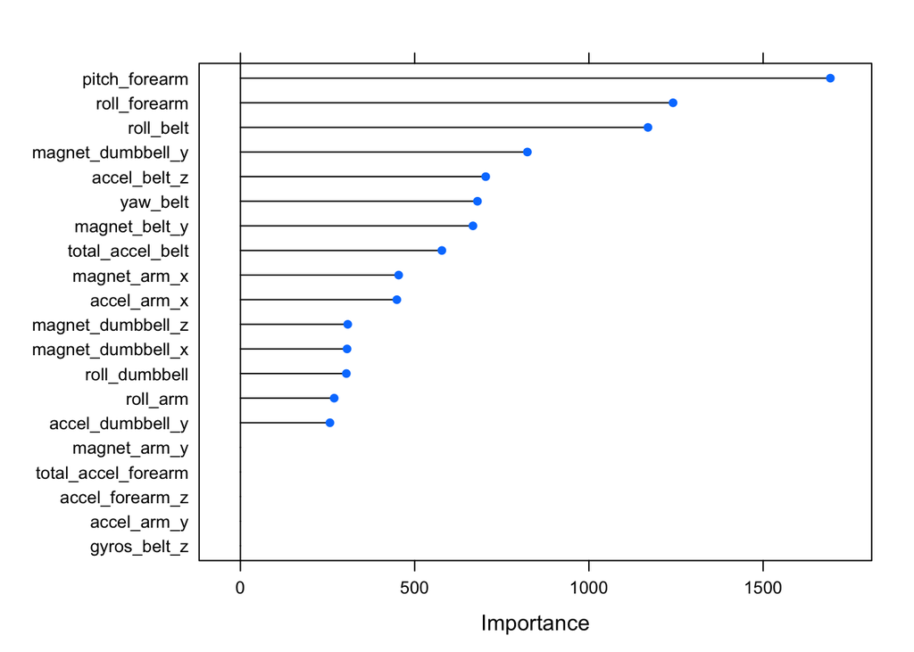

```r
cartImp <- varImp(rpartTune, scale=FALSE)
plot(cartImp, top = 20)
```

## Random forest model

Given the richness of the dataset and the small number of classes to predict, a random forest model is likely to do an excellent job. As this model is computationally intensive, we use 10-fold cross-validation with no repeats. Further, we parallelize the calculations using 6 cores. We will set seeds for the cross-validation since we’re doing this in parallel.

```r
registerDoMC(cores=6)
set.seed(33833)
seeds <- vector(mode = "list", length = 11)
for(i in 1:10) seeds[[i]] <- sample.int(1000, 22)
## For the last model:
seeds[[11]] <- sample.int(1000, 1)
cvCtrl <- trainControl(method = "cv", number=10, seeds=seeds)
rfFit <- train(classe ~ ., method="rf", data=finalTrain,
               trControl = cvCtrl)
```

The model takes about 8 minutes to compute this way.

How did we do?

```r
rfFit
```

```
## Random Forest
##
## 15699 samples
##    52 predictor
##     5 classes: 'A', 'B', 'C', 'D', 'E'
##
## No pre-processing
## Resampling: Cross-Validated (10 fold)
## Summary of sample sizes: 14130, 14128, 14129, 14129, 14130, 14130, ...
## Resampling results across tuning parameters:
##
##   mtry  Accuracy   Kappa      Accuracy SD  Kappa SD
##    2    0.9938215  0.9921841  0.002617609  0.003311380
##   27    0.9929296  0.9910558  0.002758764  0.003490432
##   52    0.9875153  0.9842061  0.002269955  0.002872638
##
## Accuracy was used to select the optimal model using  the largest value.
## The final value used for the model was mtry = 2.
```

How well does our random forest model fit the data we held out from training?

```r
set.seed(33833)
predTraining <- predict(rfFit,newdata=heldOutTrain)
confusionMatrix(predTraining, heldOutTrain$classe)
```

```
## Confusion Matrix and Statistics
##
##           Reference
## Prediction    A    B    C    D    E
##          A 1114    2    0    0    0
##          B    2  756    3    0    0
##          C    0    1  681   10    0
##          D    0    0    0  633    0
##          E    0    0    0    0  721
##
## Overall Statistics
##
##                Accuracy : 0.9954
##                  95% CI : (0.9928, 0.9973)
##     No Information Rate : 0.2845
##     P-Value [Acc > NIR] : < 2.2e-16
##
##                   Kappa : 0.9942
##  Mcnemar's Test P-Value : NA
##
## Statistics by Class:
##
##                      Class: A Class: B Class: C Class: D Class: E
## Sensitivity            0.9982   0.9960   0.9956   0.9844   1.0000
## Specificity            0.9993   0.9984   0.9966   1.0000   1.0000
## Pos Pred Value         0.9982   0.9934   0.9841   1.0000   1.0000
## Neg Pred Value         0.9993   0.9991   0.9991   0.9970   1.0000
## Prevalence             0.2845   0.1935   0.1744   0.1639   0.1838
## Detection Rate         0.2840   0.1927   0.1736   0.1614   0.1838
## Detection Prevalence   0.2845   0.1940   0.1764   0.1614   0.1838
## Balanced Accuracy      0.9987   0.9972   0.9961   0.9922   1.0000
```

What are the most important variables?

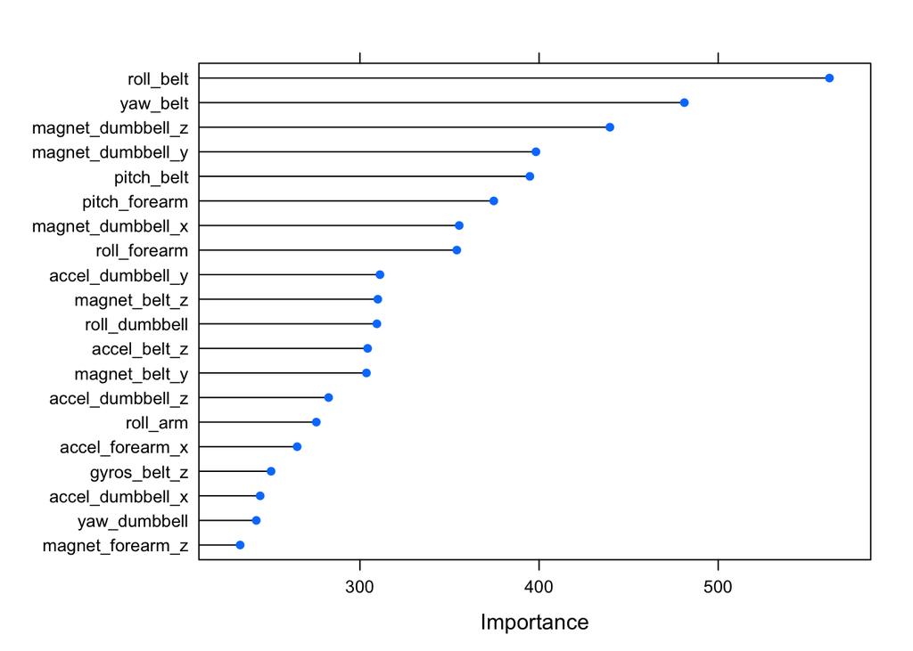

```r
rfImp <- varImp(rfFit, scale=FALSE)
plot(rfImp, top = 20)
```

We can see that many more features are used by the random forest model than by the CART model. In fact, the random forest model uses all 52 features provided.

## Applying the random forest model to the test set

For the model to properly predict the “classe” for the test data, it is first necessary to apply the same preprocessing to the test set that was done to the training set. We remove the “NA” columns and the first 7 columns with number, name, timestamp and window information.

```r
good_test <- test[,colSums(is.na(training)) ==0]
good_test <- good_test[,8:ncol(good_test)]
```

We remove the “problem_id” column, apply the centering and scaling preprocessing done for the training set, and add back the “problem_id” column.

```r
testX <- good_test[,names(good_test) != 'problem_id']
scaledTest <- predict(preProcValues, testX)
scaledTest$problem_id <- good_test$problem_id
```

Now we are ready to apply our model to the test set.

```r
predTest <- predict(rfFit,newdata=scaledTest)
answers <- as.character(predTest)
```

## Scoring on the test set

Following the instructions in the assignment, we write text files for each answer for submission to the online automatic grader.

The autograder’s feedback is that every prediction is correct! The random forest model proves to be very accurate, even though it takes some time to compute.

## References

Velloso, E.; Bulling, A.; Gellersen, H.; Ugulino, W.; Fuks, H. Qualitative Activity Recognition of Weight Lifting Exercises. Proceedings of 4th International Conference in Cooperation with SIGCHI (Augmented Human ’13) . Stuttgart, Germany: ACM SIGCHI, 2013. http://groupware.les.inf.puc-rio.br/har#ixzz3v17KTE2Y

“Predictive Modeling with R and the caret Package,” Max Kuhn, Ph.D, Pfizer Global R&D Groton, CT. max.kuhn@pfizer.com. http://www.edii.uclm.es/~useR-2013/Tutorials/kuhn/user_caret_2up.pdf